# Applied Generalized Linear (Mixed) Modelling

## Testing

```julia
fit_ngb = lm(@formula(price ~ 1 + ngb), d_sub)
coeftable(fit_ngb)
```

|  | Coef. | Std. Error | t | Pr(>\|t\|) | Lower 95% | Upper 95% |
| --- | --- | --- | --- | --- | --- | --- |
| (Intercept) | 146.821 | 7.48372 | 19.62 | <1e-70 | 132.133 | 161.509 |
| ngb: Friedrichshain | 8.19951 | 10.6449 | 0.77 | 0.4413 | -12.6929 | 29.0919 |
| ngb: Hellersdorf | 46.1265 | 10.9175 | 4.22 | <1e-04 | 24.6991 | 67.5539 |
| ngb: Hohenschönhausen | 9.10781 | 10.9175 | 0.83 | 0.4044 | -12.3196 | 30.5352 |
| ngb: Kreuzberg | -21.2281 | 10.0817 | -2.11 | 0.0355 | -41.0151 | -1.44118 |
| ngb: Lichtenberg | 106.806 | 8.92754 | 11.96 | <1e-29 | 89.2839 | 124.327 |
| ngb: Marzahn | 0.557313 | 10.9175 | 0.05 | 0.9593 | -20.8701 | 21.9847 |
| ngb: Mitte | -4.86271 | 10.4679 | -0.46 | 0.6424 | -25.4077 | 15.6822 |
| ngb: Neukölln | 33.352 | 10.3607 | 3.22 | 0.0013 | 13.0174 | 53.6866 |
| ngb: Pankow | -29.2994 | 10.9175 | -2.68 | 0.0074 | -50.7268 | -7.87195 |
| ngb: Prenzlauer Berg | 40.0487 | 10.8449 | 3.69 | 0.0002 | 18.7637 | 61.3336 |
| ngb: Reinickendorf | 42.2467 | 10.2612 | 4.12 | <1e-04 | 22.1075 | 62.3859 |
| ngb: Schöneberg | -38.9272 | 10.6449 | -3.66 | 0.0003 | -59.8196 | -18.0348 |
| ngb: Spandau | -33.3677 | 10.8449 | -3.08 | 0.0022 | -54.6527 | -12.0828 |
| ngb: Steglitz | -46.3484 | 9.81855 | -4.72 | <1e-05 | -65.6189 | -27.0779 |
| ngb: Tempelhof | -62.6469 | 11.4316 | -5.48 | <1e-07 | -85.0832 | -40.2106 |
| ngb: Treptow | 38.8887 | 10.7754 | 3.61 | 0.0003 | 17.7402 | 60.0373 |
| ngb: Wedding | -48.4814 | 10.1684 | -4.77 | <1e-05 | -68.4385 | -28.5243 |
| ngb: Weißensee | -30.6431 | 10.5246 | -2.91 | 0.0037 | -51.2994 | -9.98689 |

## Testing

```julia
#| echo: true
m0 = lm(@formula(price ~ 1), d_sub)
m1 = lm(@formula(price ~ 1 + ngb), d_sub)
r²0 = r2(m0)
r²1 = r2(m1)
n = nrow(d_sub)
p1 = length(coef(m1)) - 1
p0 = length(coef(m0)) - 1
f_stat = ((r²1 - r²0) / (p1 - p0)) / ((1 - r²1) / (n - p1 - 1))
p_val = 1 - cdf(FDist(p1 - p0, n - p1 - 1), f_stat)
"F-statistic: $(round(f_stat, digits=2)), p-value: $(round(p_val, digits=4))"
```

[output not shown]

## an graphical way to think about it

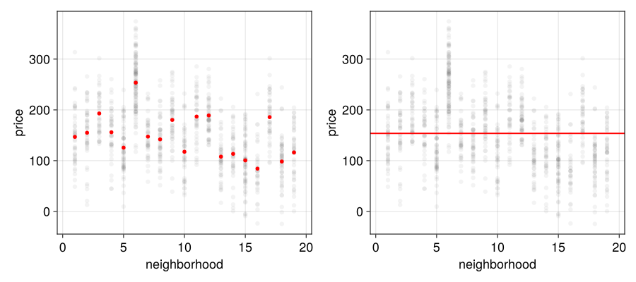

## Coming back to a 2x2 design. Which order to test effects?

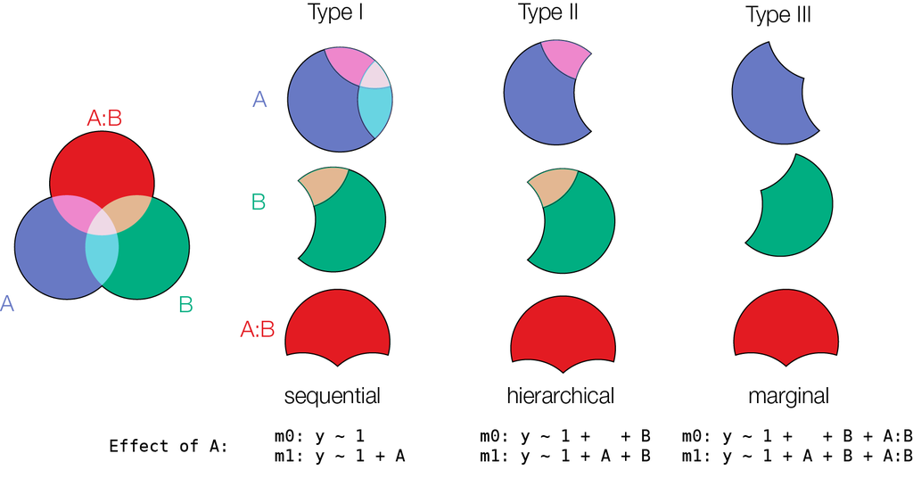

venn diagram

## Model comparison does not care about recoding

|  | Coef. | Std. Error | t | Pr(>\|t\|) | Lower 95% | Upper 95% |
| --- | --- | --- | --- | --- | --- | --- |
| (Intercept) | -37.7034 | 41.5057 | -0.91 | 0.3714 | -122.724 | 47.3172 |
| wt | 54.774 | 10.9877 | 4.99 | <1e-04 | 32.2666 | 77.2813 |
| am: 1 | 27.2841 | 78.5006 | 0.35 | 0.7308 | -133.517 | 188.085 |
| wt & am: 1 | -11.3233 | 32.382 | -0.35 | 0.7292 | -77.6548 | 55.0083 |

|  | Coef. | Std. Error | t | Pr(>\|t\|) | Lower 95% | Upper 95% |
| --- | --- | --- | --- | --- | --- | --- |
| (Intercept) | -24.0614 | 39.2503 | -0.61 | 0.5448 | -104.462 | 56.3392 |
| wt | 49.1124 | 16.191 | 3.03 | 0.0052 | 15.9466 | 82.2781 |
| am_eff | 27.2841 | 78.5006 | 0.35 | 0.7308 | -133.517 | 188.085 |
| wt & am_eff | -11.3233 | 32.382 | -0.35 | 0.7292 | -77.6548 | 55.0083 |

Walds-T test cares (simple vs. main effects)

```julia
r²_dummy = GLM.r2(m_dummy)
r²_effect = GLM.r2(m_effect)
"R² dummy coding: $(round(r²_dummy, digits=4)), R² effect coding: $(round(r²_effect, digits=4))"
```

```
"R² dummy coding: 0.6411, R² effect coding: 0.6411"
```

model comparison does not care!

# Assumptions

- **L**inearity of responses
- **I**ndependence
- **N**ormality
- **E**qual variance

## Linearity of responses

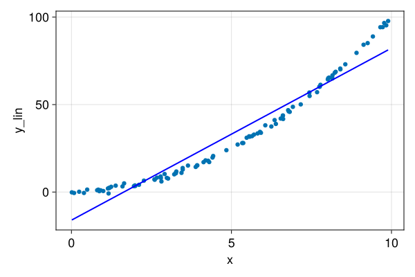

## Linear response

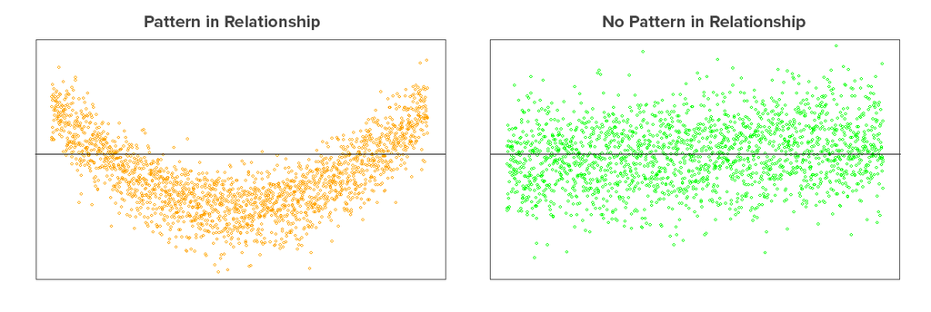

## Independence of residuals

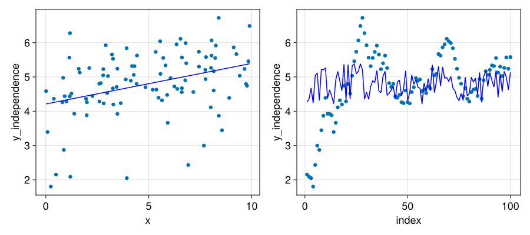

## Normality of residuals

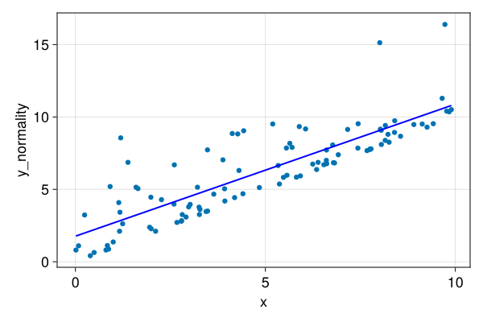

## Checking Assumptions: Normality using QQplots

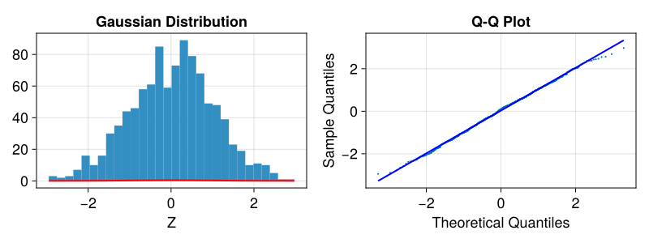

Source: [Sean Kross](https://seankross.com/2016/02/29/A-Q-Q-Plot-Dissection-Kit.html)

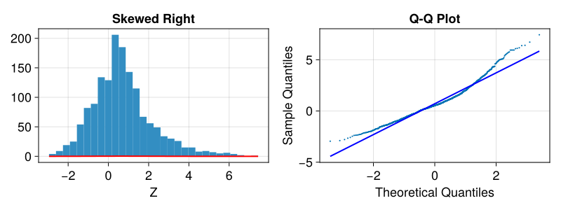

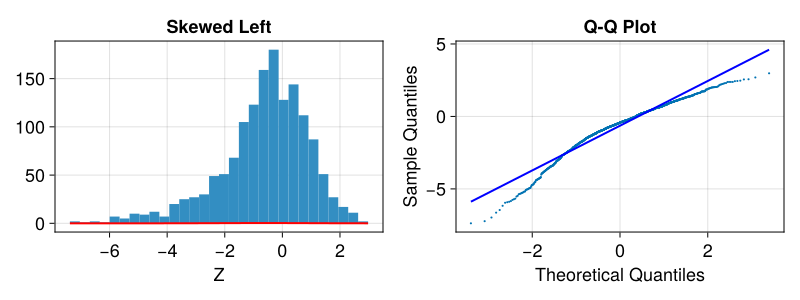

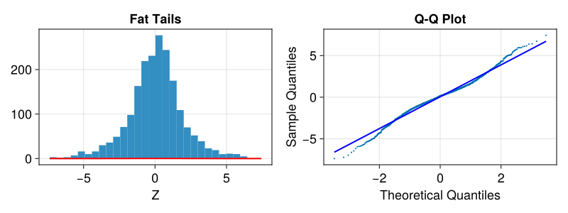

## A nice trick

imulate datasets with same specifications and compare

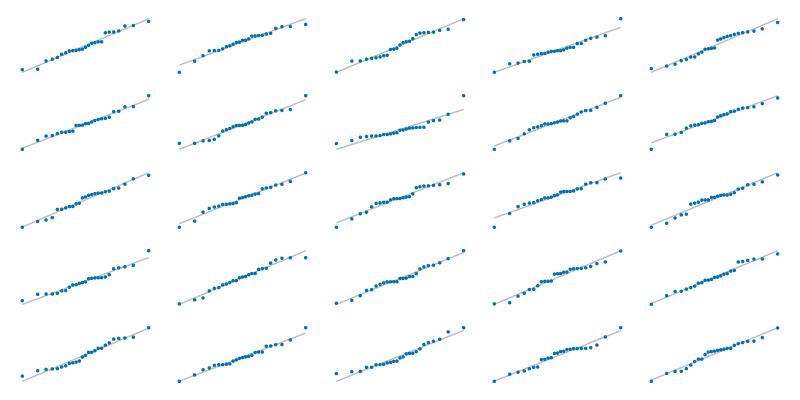

## Equal variance

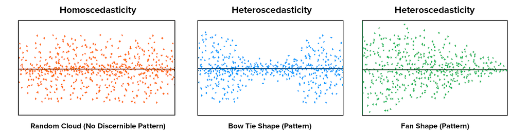

homoscedasticity

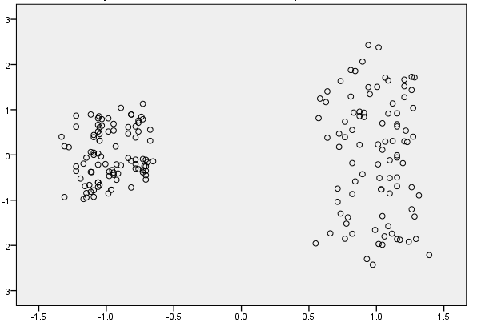

homoscedasticity categorical

# Statistics Philosophy

## Fisher

- p-values are *a continuous measure of evidence against the $H_0$*
- “Significant” p-values can be defined ad-hoc, i.e. what you think is enough evidence for this one test
- a sensitivity analysis (~power analysis) can be performed but is not necessary
- General idea: A single experiment should inform your decisions

## Neyman-Pearson

- p-values are only used to be threshold by $\alpha$
- the pre-analysis fixed $\alpha$ denotes the error-probability to receive false positives
- a power analysis is required and is part of the test
- a p-value of 0.049 and 0.001 give the same evidence (with $\alpha=0.05$)
- General idea: Its all about long-term properties. A single experiment does not really help

## Type I vs. Type II errors

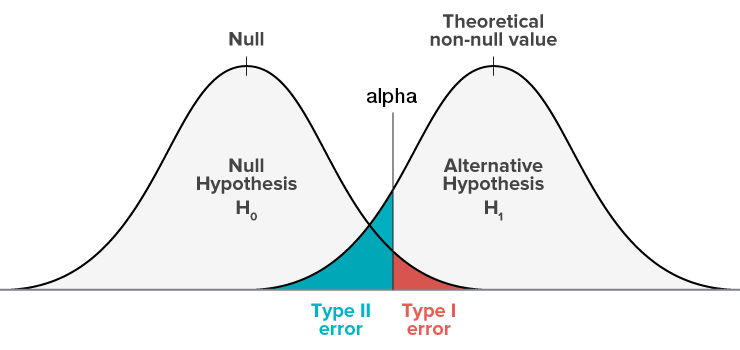

type1errors

[image source](https://grasshopper.com/blog/the-errors-of-ab-testing-your-conclusions-can-make-things-worse/)

## Type Errors

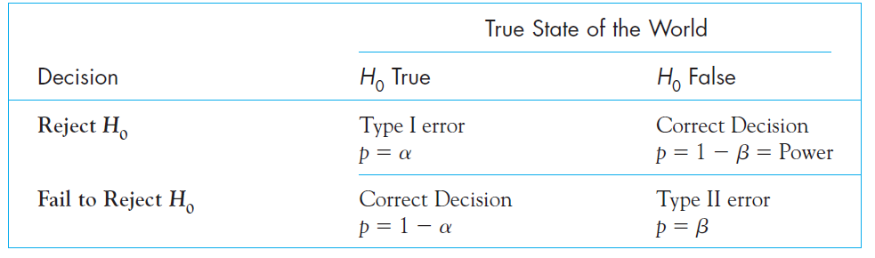

typeerrors

## NHST

A dark mix between Fisher & Neyman-Pearson is currently used. This is evident by calculating a p-value, p-values below $\alpha$ are significant (NP). But exact p-values are still reported.

This is a very popular mix - but is not consistent. Either you want to accept / reject a finding (and be correct on the long run) or you want to identify how much evidence you have from your sample (and act according to how much evidence you have).

## Bayes

- parameter estimates (combined with the **apropriate** aka **fully informed** prior) reflect the probability of the true parameter being this value
- P-Values are of no use - one can contrast two opposing hypotheses directly (e.g. model-selection)
- usually not interested in testing hypotheses, but more on estimating likely ranges of parameters

## An intuition on the difference between Bayes & Frequentist

- Frequentist:
  - All about the sampling distribution
  - probabilities are frequencies of (hypothetical) outcomes
  - Hypothetical Population and experiments (=> sampling distribution)
  - A population-parameter has a true value
  - “top down”
- Bayesian:
  - All about the (subjective*) probabilities of parameters
  - probabilities are plausibilities/certainties
  - population-parameters are uncertain
  - “bottom up”

They can result in exactly the same numbers. But interpretation vastly different!

- sometimes called subjective because of subjective choice of priors

## Be both if you can!

Come join our Seminar: “Statistical Rethinking Reading Club” next semester

[figure not shown]

statistical rethinking book

> “This is a rare and valuable book that combines readable explanations, computer code, and active learning.” —Andrew Gelman, Columbia University

> “…an impressive book that I do not hesitate recommending for prospective data analysts and applied statisticians!” —Christian Robert, Université Paris-Dauphine (review)

> “A pedagogical masterpiece…” —Rasmus Bååth, Lund University

> “The content of this book has been developed over a decade+ of McElreath’s teaching and mentoring of graduate students, post docs, and other colleagues, and it really shows.” —Brian Wood, Yale

> “…omg suddenly everything makes sense…” —Ecstatic anonymous reader

# Linear models all the way down!

## It’s all linear models

## Correlation

$$r = \frac{cov_{XY}}{\sigma_X\sigma_Y}$$
$$Y = \beta_0 + X\beta_1$$
$$r = \beta_1\frac{\sigma_X}{\sigma_Y}$$

Alternative: standardize both Y & X (e.g. $Y^* = \frac{Y}{\sigma_Y}$) before fitting the regression, you will receive correlations

## t-test

Test for two groups: $t = \frac{\hat \mu_1 - \hat \mu_2}{\sqrt{SE_1^2 + SE_2^2}}$

```julia
# Welch's t-test equivalent
#y0 = d.reactiontime[d.round_square .== "round"]
#y1 = d.reactiontime[d.round_square .== "square"]
#t_stat = (mean(y0) - mean(y1)) / sqrt(var(y0)/length(y0) + var(y1)/length(y1))
#df_t = (var(y0)/length(y0) + var(y1)/length(y1))^2 /
#        ((var(y0)/length(y0))^2/(length(y0)-1) + (var(y1)/length(y1))^2/(length(y1)-1))
#p_val_t = 2 * (1 - cdf(TDist(df_t), abs(t_stat)))
#"t-statistic: $round(t_stat, digits=2), p-value: $round(p_val_t, digits=4)"#

# Linear model equivalent
#fit_t = lm(@formula(reactiontime ~ 1 + round_square), d)
#coeftable(fit_t)
```

## ANOVA

```julia
d = mtcars

# ANOVA via model comparison
l1 = lm(@formula(hp ~ 1 + gear), d)
l0 = lm(@formula(hp ~ 1), d)
r²_l1 = GLM.r2(l1)
r²_l0 = GLM.r2(l0)
n_anova = nrow(d)
p_l1 = length(coef(l1)) - 1
p_l0 = length(coef(l0)) - 1
f_anova = ((r²_l1 - r²_l0) / (p_l1 - p_l0)) / ((1 - r²_l1) / (n_anova - p_l1 - 1))
p_anova = 1 - cdf(FDist(p_l1 - p_l0, n_anova - p_l1 - 1), f_anova)
"F-statistic: $(round(f_anova, digits=2)), p-value: $(round(p_anova, digits=4))"
```

[output not shown]

## ANCOVA

```julia
# Bla Using the synthetic airbnb data
#d_sub800 = view(dair, 1:800, :)

#l1_ancova = lm(@formula(price ~ 1 + bedrooms + reviews), d_sub800)
#l0_ancova = lm(@formula(price ~ 1 + bedrooms), d_sub800)
#r²_1 = r2(l1_ancova)
#r²_0 = r2(l0_ancova)
#n_a = nrow(d_sub800)
#p_1 = length(coef(l1_ancova)) - 1
#p_0 = length(coef(l0_ancova)) - 1
#f_ancova = ((r²_1 - r²_0) / (p_1 - p_0)) / ((1 - r²_1) / (n_a - p_1 - 1))
#p_ancova = 1 - cdf(FDist(p_1 - p_0, n_a - p_1 - 1), f_ancova)
#"F-statistic: $round(f_ancova, digits=2), p-value: $round(p_ancova, digits=4)"
```

## recommendations

I like these books: - Statistical Rethinking - (more math) Advanced Data Analysis from an elemental point view (Cosma Shalizi)

I like these webpages: https://www.flutterbys.com.au/stats/

## And thats it!

[figure not shown]